# DNA Profile 2016

DSPG Business Innovation Team

7/9/2019

## 1. Read Data

Set year filter here.

```r
year <- 2016
path <- sprintf("./data/working/DNA_Aggregated/dna_%s.RDS", year)
dna.dt <- read_rds(path) %>%
  as.data.table()
```

This is the profiling for the year 2016.

## 2. Profile

Tidying the data.

```r
#Unlist columns
dna.dt <- dna.dt %>%
  dt_mutate(
    subject_codes = subject_codes %>% map_chr(.x = ., ~paste0(.x, collapse = ", "))
  )
```

General description.

```r
#Dimension
dna.dt %>%
  introduce()
```

```
##      rows columns discrete_columns continuous_columns all_missing_columns
## 1: 289962      33               33                  0                   0
##    total_missing_values complete_rows total_observations memory_usage
## 1:                 8985        280995            9568746   1527070304
```

```r
#Tidy for head screenshot
dna.dt <- dna.dt %>%
  dplyr::select(c(an, title, body, publisher_name,
                  company_codes, subject_codes, everything()))
```

Names of variables.

```r
#Variable Names
names(dna.dt) %>% paste0(., collapse = ", ")
```

```
## [1] "an, title, body, publisher_name, company_codes, subject_codes, copyright, art, modification_datetime, company_codes_occur, company_codes_about, company_codes_lineage, snippet, publication_date, market_index_codes, credit, currency_codes, region_of_origin, ingestion_datetime, modification_dat…
```

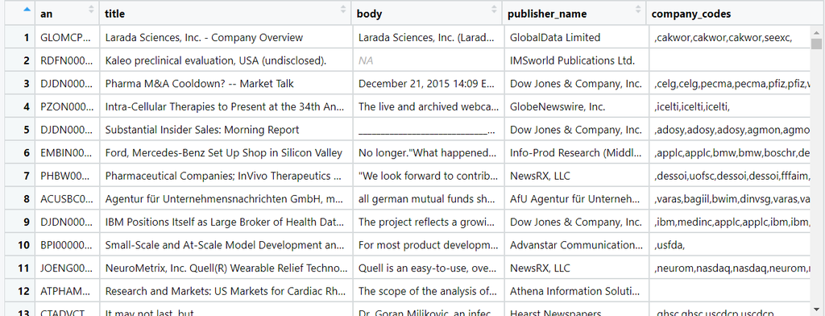

```r
plot_str(dna.dt)
```

```r
#Structure of Data
str(dna.dt)
```

```
## Classes 'data.table' and 'data.frame':   289962 obs. of  33 variables:
##  $ an                       : chr  "LAWRET0020160708ec7700003" "ATPHAM0020160123ec1j000dy" "DRGW000020161209ecc90002m" "DJDN000020160111ec1b0035r" ...
##  $ title                    : chr  "Opioid crisis: How did we get here?" "Maxon Foundation Gives $3 Million for Region's Heart Care" "Drugs and Therapies; Findings from School of Pharmacy Broaden Understanding of Pharmaceutical Research and Biop"| __truncated__ "KaloBios Pharmaceuticals Adds Two …
##  $ body                     : chr  "Here are three articles from our archives that explain how we arrived at this crisis point.\n\nTheodore Cicero "| __truncated__ "\"This gift allows us to create two state-of-the-art ambulatory care centers and ensure access to care when peo"| __truncated__ "The…
##  $ publisher_name           : chr  "Community Newspaper Holdings, Inc." "Athena Information Solutions Pvt. Ltd." "NewsRX, LLC" "Dow Jones & Company, Inc." ...
##  $ company_codes            : chr  ",purdp,wsguvl,purdp,purdp,rbwdjf,unvpnl,unvpnl,wsguvl,wsguvl," ",usbank,munshi,munshi,usbank,usbank,staban," ",elsv,elsv," ",klbspi,monco,schplo,klbspi,klbspi,monco,monco,nasdaq,nasdaq,schplo,schplo,turiph,turiph,pfiz," ...
##  $ subject_codes            : chr  "ccat, gheroi, gabus, gcat, gcom, gsoc" "ccat" "cappro, c13, c22, ccat, ncat, nfact, nfcpin" "c411, cboard, neqac, nfiac, ntop, nttwn, c41, ccat, ncat, ndj, nfact, nfcpex, nfcpin, redit" ...
##  $ copyright                : chr  "Copyright 2016 The Eagle-Tribune / Community Newspaper Holdings, Inc. (CNHI). All Rights Reserved. Distributed "| __truncated__ "Copyright © 2016. Contify.com   " "© Copyright 2016, Drug Week via NewsRx.com " "Copyright © 2016, Dow Jones & Company, Inc.   " ...
##  $ art                      : chr  "" "" "" "" ...
##  $ modification_datetime    : chr  "1481644789000" "1453560551000" "1481324976000" "1452540495000" ...
##  $ company_codes_occur      : chr  ",wsguvl,unvpnl,purdp," ",usbank,munshi," ",elsv," ",turiph,schplo,nasdaq,monco,klbspi," ...
##  $ company_codes_about      : chr  ",wsguvl,purdp," ",usbank," "" ",schplo,monco,klbspi," ...
##  $ company_codes_lineage    : chr  "" ",staban," "" ",pfiz," ...
##  $ snippet                  : chr  "Lawmakers meet Wednesday to try to finalize legislation to solve the nation's opioid crisis. It's an issue that"| __truncated__ "Jan. 19 -- A $3 million gift from the Maxon Foundation, U.S. Bank, N.A., Trustee, of Cincinnati, Ohio, will fun"| __truncated__ "201…
##  $ publication_date         : chr  "1467849600000" "1453161600000" "1481241600000" "1452540240000" ...
```

[output cut: 20 more lines]

```r
#Percent Missing by Variable
percent.missing <- dna.dt %>%
  is.na.data.frame() %>%
  apply(., 2, mean) %>%
  round(3)
percent.missing
```

```
##                        an                     title
##                     0.000                     0.000
##                      body            publisher_name
##                     0.024                     0.000
##             company_codes             subject_codes
##                     0.000                     0.000
##                 copyright                       art
##                     0.000                     0.000
##     modification_datetime       company_codes_occur
##                     0.000                     0.000
##       company_codes_about     company_codes_lineage
##                     0.000                     0.000
##                   snippet          publication_date
##                     0.007                     0.000
##        market_index_codes                    credit
##                     0.000                     0.000
##            currency_codes          region_of_origin
##                     0.000                     0.000
##        ingestion_datetime         modification_date
##                     0.000                     0.000
##               source_name             language_code
##                     0.000                     0.000
##              region_codes company_codes_association
##                     0.000                     0.000
##              person_codes                    byline
##                     0.000                     0.000
##   company_codes_relevance               source_code
##                     0.000                     0.000
##                word_count            industry_codes
##                     0.000                     0.000
##      publication_datetime                    action
##                     0.000                     0.000
##             document_type
##                     0.000
```

```r
#plot_bar(dna.dt$action)
```

# 3. Preliminary Cleaning

#### Word Count (Body of Text)

Here, we filter out articles with body text less than 10 words in length, as this indicates is not a “true” article in the scope of our interest. For plotting, we trimmed at 5000 length word. The new data is renamed so the original is still available for later use.

```r
#Cleaning out WC
dna.2.dt <- dna.dt %>%
  dt_mutate(
    word_count = word_count %>% as.numeric()
  ) %>%
  dt_filter(word_count > 10 & word_count < 2000)

#Summary
summary(dna.2.dt$word_count)
```

```
##    Min. 1st Qu.  Median    Mean 3rd Qu.    Max.
##    11.0   207.0   359.0   486.2   647.0  1999.0
```

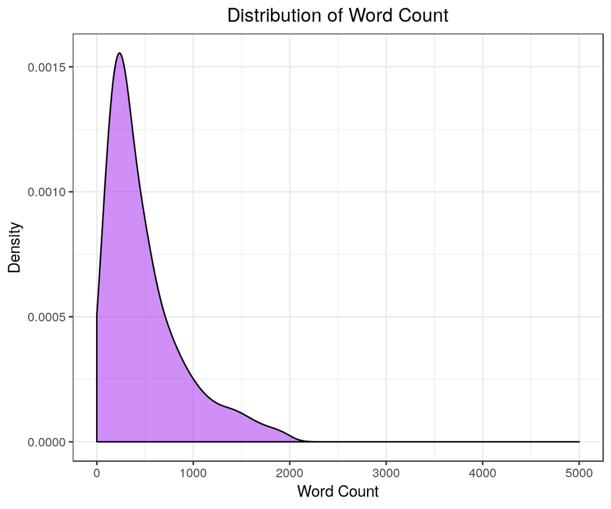

```r
#Distribution
ggplot(dna.2.dt, aes(x = word_count)) +
  geom_density(fill = "purple", alpha = 0.5, adjust = 4, trim = FALSE) +
  labs(
    x = "Word Count",
    y = "Density",
    title = "Distribution of Word Count"
  ) +
  xlim(0, 5000)
```

#### Sources (of Publishers)

```r
#Data frame for all combos of unique codes, names
asd <- dna.2.dt[, list(source_code, source_name, publisher_name)] %>% unique()

#Unique source codes
dna.2.dt$source_code %>% unique() %>% length()
```

```
## [1] 2038
```

```r
#" " names
dna.2.dt$source_name %>% unique() %>% length()
```

```
## [1] 2014
```

```r
#Unique publisher names
dna.2.dt$publisher_name %>% unique() %>% length()
```

```
## [1] 832
```

```r
#Joining for unique data frame (writen out)
asd <- left_join(asd, dna.2.dt[, list(source_code, source_name, publisher_name)] %>%
                   group_by(source_code) %>%
                   summarise(
                     count_source_code = n()
                   ), by = "source_code")

asd <- left_join(
  asd, dna.2.dt[, list(source_code, source_name, publisher_name)] %>%
    group_by(source_name) %>%
    summarise(
      count_source_name = n()
    ), by = "source_name"
)

asd <- left_join(
  asd, dna.2.dt[, list(source_code, source_name, publisher_name)] %>%
    group_by(publisher_name) %>%
    summarise(
      count_publisher_name = n()
    ), by = "publisher_name"
)

#write_csv(unique(asd), "./data/working/DNA_Aggregated/unique_publisher_sources.csv")

#Top 10 Unique Names
dna.2.dt %>%
  group_by(publisher_name) %>%
  summarise(
    Count = n()
  ) %>%
  arrange(desc(Count)) %>%
  dt_mutate(
    publisher_name = publisher_name %>%
      as.factor() %>%
      forcats::fct_reorder(., Count)
  ) %>%
  slice(1:10)
```

```
##                            publisher_name Count
## 1                             NewsRX, LLC 63091
## 2               Dow Jones & Company, Inc. 44087
## 3  Athena Information Solutions Pvt. Ltd. 19675
## 4                     Theflyonthewall.com 13587
## 5           Thomson Reuters (Markets) LLC 13288
## 6                   Elsevier Science Ltd.  9436
## 7                      GlobalData Limited  8443
## 8                     Business Wire, Inc.  7444
## 9             News Bites Pty Ltd (Europe)  6084
## 10                    GlobeNewswire, Inc.  5630
```

[figure not shown]

#### Company Names

Look at unique company names and the top 10 mentioned in these articles for 2016 (in combination with others).

```r
#Str_split to get list of char vectors of region
dna.2.dt <- dna.2.dt %>%
  dt_mutate(
    company_codes = str_split(company_codes, ",") %>%
      lapply(., function(x) {x[c(-1, -length(x))]})    #storing subj codes as nested list of char vector
  )

#Unique
dna.2.dt$company_codes %>%
  unlist() %>%
  unique() %>%
  length()
```

```
## [1] 27577
```

```r
#Summary
company.counts <- dna.2.dt$company_codes %>% map_dbl(.x = ., ~length(.x))
company.counts %>% summary()
```

```
##    Min. 1st Qu.  Median    Mean 3rd Qu.    Max.
##   0.000   3.000   5.000   6.962   8.000 310.000
```

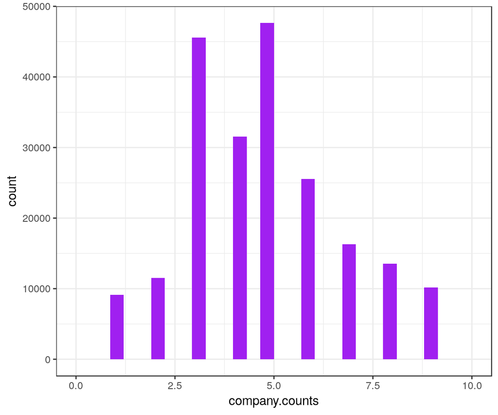

```r
#Histogram
tibble(company.counts = company.counts) %>%
  ggplot(aes(x = company.counts)) +
  geom_histogram(fill = "purple") +
  # geom_density(fill = "purple", adjust = 5) +
  xlim(0, 10)
```

```r
#Top 10
data.table(company = dna.2.dt$company_codes %>%
             unlist() %>%
             table() %>%
             names(),
           counts = dna.2.dt$company_codes %>%
             unlist() %>%
             table() %>%
             as.numeric()) %>%
  dt_arrange(counts) %>%
  Rev(margin = 1) %>%
  slice(1:10)
```

```
##    company counts
## 1    seexc 101220
## 2    usfda  96369
## 3     pfiz  23774
## 4   nasdaq  15922
## 5   wtsnph  14035
## 6   jonjon  13794
## 7   trimel  13233
## 8     byer  11359
## 9   brstmy  10309
## 10   lilye  10121
```

#### Company Names (About)

Look at unique company names (about) and the top 10 mentioned in these articles for 2016 (in combination with others).

```r
#Str_split to get list of char vectors of region
dna.2.dt <- dna.2.dt %>%
  dt_mutate(
    company_codes_about = str_split(company_codes_about, ",") %>%
      lapply(., function(x) {x[c(-1, -length(x))]})    #storing subj codes as nested list of char vector
  )

#Unique
dna.2.dt$company_codes_about %>%
  unlist() %>%
  unique() %>%
  length()
```

```
## [1] 12322
```

```r
#Summary
company.counts <- dna.2.dt$company_codes_about %>% map_dbl(.x = ., ~length(.x))
company.counts %>% summary()
```

```
##    Min. 1st Qu.  Median    Mean 3rd Qu.    Max.
##   0.000   1.000   1.000   1.224   2.000  35.000
```

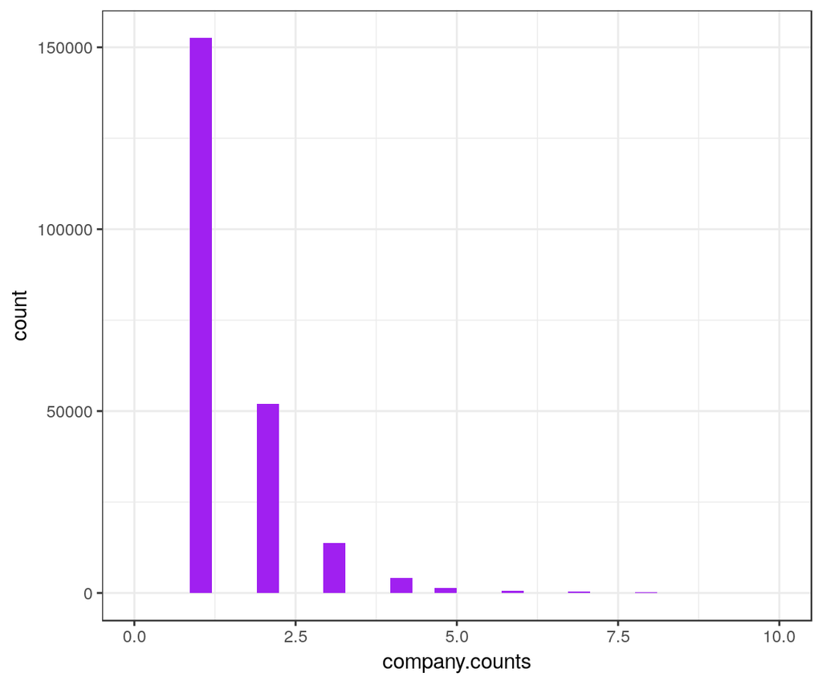

```r
#Histogram
tibble(company.counts = company.counts) %>%
  ggplot(aes(x = company.counts)) +
  geom_histogram(fill = "purple") +
  # geom_density(fill = "purple", adjust = 5) +
  xlim(0, 10)
```

```r
#Top 10
data.table(company = dna.2.dt$company_codes_about %>%
             unlist() %>%
             table() %>%
             names(),
           counts = dna.2.dt$company_codes_about %>%
             unlist() %>%
             table() %>%
             as.numeric()) %>%
  dt_arrange(counts) %>%
  Rev(margin = 1) %>%
  slice(1:10)
```

```
##    company counts
## 1    usfda  20211
## 2     pfiz   5038
## 3   trimel   4477
## 4   schplo   3275
## 5     byer   3274
## 6     myln   3260
## 7   jonjon   2960
## 8   allgop   2645
## 9    lilye   2629
## 10  brstmy   2550
```

```r
#Notes

#- Articles w/ no company codes
#- Count how many only fda, sec, and nasdaq (locate, filter)
#- Subject_code, new_product (investigate?) ns? C22 new product? CDNN innovation, cgvfil gov files?
#- Filtering by keywords "in the text body" / subject code?
#- iterate "for all years"
```

#### Articles With No Company Code?

```r
#Company Codes About
map_lgl(.x = company.about$company_codes_about, is_empty) %>% sum()
map_lgl(company.about$company_codes_about, is_empty) %>% mean()

#Company Codes
map_lgl(.x = company$company_codes, is_empty) %>% sum()
map_lgl(company$company_codes, is_empty) %>% mean()

#Both
map2_lgl(.x = company$company_codes, .y = company.about$company_codes_about, ~is_empty(.x) & is_empty(.y)) %>%
  sum()
map2_lgl(.x = company$company_codes, .y = company.about$company_codes_about, ~is_empty(.x) & is_empty(.y)) %>%
  mean() %>%
  round(4)

#Either
map2_lgl(.x = company$company_codes, .y = company.about$company_codes_about, ~is_empty(.x) | is_empty(.y)) %>%
  sum()
map2_lgl(.x = company$company_codes, .y = company.about$company_codes_about, ~is_empty(.x) | is_empty(.y)) %>%
  mean() %>%
  round(4)
```

[output not shown]

The data suggest that 47549 “Company Codes About” are missing, or roughly 0.1743 proportion of the data; while for companies 14751 are empty, comprising roughly 0.0541 of these data. Considering the overlap between these two missing values, 14751 are missing both company and company about; comprising roughly 0.0541 proportion of the data. Lastly, 47549 are missing either value, comprising 0.1743 proportion of the data from 2016.

#### Locate and Filter Company (FDA, SEC, NASDAQ)

```r
#Filtered df by company != FDA, SEC, or NASDAQ
dna.3.dt <- dna.2.dt %>%
  dt_mutate(
 #   company_codes = str_split(company_codes, ",") %>%
#      lapply(., function(x) {x[c(-1, -length(x))]}),    #storing subj codes as nested list of char vector
#    company_codes_about = str_split(company_codes_about, ",") %>%
#      lapply(., function(x) {x[c(-1, -length(x))]}),    #storing subj codes as nested list of char vector
    filter_company = ifelse(map_lgl(.x = company_codes, ~length(.x) != 1),
                            FALSE,
                            map_lgl(.x = company_codes, ~str_detect(.x, "usfda|seexc|nasdaq") %>% any(isTRUE(.)))),
    filter_company_about = ifelse(map_lgl(.x = company_codes_about, ~length(.x) != 1),
                                  FALSE,
                                  map_lgl(.x = company_codes_about, ~str_detect(.x, "usfda|seexc|nasdaq") %>% any(isTRUE(.))))
  )

#Count how many have only fda, sec, nasdaq in company, company about, or either.
dna.3.dt$filter_company %>% sum()
```

```
## [1] 1408
```

```r
dna.3.dt$filter_company_about %>% sum()
```

```
## [1] 4998
```

```r
(dna.3.dt$filter_company | dna.3.dt$filter_company_about) %>% sum()
```

```
## [1] 6335
```

```r
#Filter out either variable
dna.3.dt <- dna.3.dt %>%
  dt_mutate(
    filter_either = dna.3.dt$filter_company | dna.3.dt$filter_company_about
  ) %>%
  dt_filter(filter_either != TRUE) %>%
  dt_select(-c(filter_company, filter_company_about, filter_either))
```

#### Industry Investigation

```r
#Number of Unique Industry codes
dna.3.dt <- dna.3.dt %>%
  dt_mutate(
    industry_codes_empty =  map(.x = industry_codes, ~ifelse(.x %in% "", character(0), .x)),
    industry_codes = str_split(industry_codes, ",") %>%
      lapply(., function(x) {x[c(-1, -length(x))]}),    #storing industry codes as nested list of char vector
    industry_codes = map(.x = industry_codes, ~ifelse(.x %in% "", character(0), .x))
  )

#Industry codes
#Pharmaceuticals
#Number of Empty INdustry Codes
map_lgl(.x = dna.3.dt$industry_codes_empty, ~is.na(.x)) %>% sum()
```

```
## [1] 0
```

```r
map_lgl(.x = dna.3.dt$industry_codes_empty, ~is.na(.x)) %>% mean()
```

```
## [1] 0
```

```r
#Most Common Industry Codes (10)
data.table(industry = dna.3.dt$industry_codes %>%
             unlist() %>%
             table() %>%
             names(),
           counts = dna.3.dt$industry_codes %>%
             unlist() %>%
             table() %>%
             as.numeric()) %>%
  dt_arrange(counts) %>%
  Rev(margin = 1) %>%
  slice(1:10)
```

```
##    industry counts
## 1      i951 266513
## 2      i257 202088
## 3      i372  97833
## 4     i2569  67628
## 5    iphmed  63301
## 6   idrugty  43064
## 7    ibioph  42729
## 8  itheradv  39150
## 9    ifinal  17934
## 10     ibcs  13840
```

```r
#Pharma
map_lgl(.x = dna.3.dt$industry_codes, ~c("i257") %in% .x) %>% sum()
```

```
## [1] 202088
```

```r
#Medical Equipment/Supplies
map_lgl(.x = dna.3.dt$industry_codes, ~c("i372") %in% .x ) %>% sum()
```

```
## [1] 97833
```

```r
#Remove FDA Source Codes (from publisher)
dna.3.dt <- dna.3.dt %>%
  dt_mutate(
    source_filter = str_detect(source_code, paste0(c("USFOD", "WCUSFOD", "FDADOC", "FDADB", "FDDB"), collapse = "|"))
  )

#Number of Publisher sources coming from FDA
dna.3.dt$source_filter %>% sum()
```

```
## [1] 2478
```

```r
#Filter and remove sourc_filter variable
dna.3.dt <- dna.3.dt %>%
  dt_filter(source_filter %in% FALSE) %>%
  dt_select(-source_filter)
```

#### Summary of Final (FDA & WC) Filtered Data

```r
#Dimension
dim(dna.3.dt)
```

```
## [1] 264054     34
```

```r
#Summary of final data
str(dna.3.dt)
```

```
## Classes 'data.table' and 'data.frame':   264054 obs. of  34 variables:
##  $ an                       : chr  "LAWRET0020160708ec7700003" "ATPHAM0020160123ec1j000dy" "DRGW000020161209ecc90002m" "DJDN000020160111ec1b0035r" ...
##  $ title                    : chr  "Opioid crisis: How did we get here?" "Maxon Foundation Gives $3 Million for Region's Heart Care" "Drugs and Therapies; Findings from School of Pharmacy Broaden Understanding of Pharmaceutical Research and Biop"| __truncated__ "KaloBios Pharmaceuticals Adds Two …
##  $ body                     : chr  "Here are three articles from our archives that explain how we arrived at this crisis point.\n\nTheodore Cicero "| __truncated__ "\"This gift allows us to create two state-of-the-art ambulatory care centers and ensure access to care when peo"| __truncated__ "The…
##  $ publisher_name           : chr  "Community Newspaper Holdings, Inc." "Athena Information Solutions Pvt. Ltd." "NewsRX, LLC" "Dow Jones & Company, Inc." ...
##  $ company_codes            :List of 264054
##   ..$ : chr  "purdp" "wsguvl" "purdp" "purdp" ...
##   ..$ : chr  "usbank" "munshi" "munshi" "usbank" ...
##   ..$ : chr  "elsv" "elsv"
##   ..$ : chr  "klbspi" "monco" "schplo" "klbspi" ...
##   ..$ : chr  "ardely" "ardely" "ardely" "berlab" ...
##   ..$ : chr  "myln" "intth" "myln" "myln" ...
##   ..$ : chr  "glxo" "glxo" "usfda" "usfda" ...
##   ..$ : chr  "oncoms" "amemed" "amemed" "congen" ...
##   ..$ : chr  "cellth" "cellth" "cellth" "usfda" ...
##   ..$ : chr  "eucmm" "sndoz" "sndoz" "usfda" ...
##   ..$ : chr  "amge" "amge" "amge" "cytkin" ...
##   ..$ : chr  "bcrdi" "cytclp" "nmcrp" "wsgr" ...
##   ..$ : chr  "cambrf" "cambrf"
##   ..$ : chr  "amrcan" "jonjon" "jonjon" "ntnct" ...
##   ..$ : chr  "crgna" "clecft" "crgna" "crgna" ...
##   ..$ : chr  "apifgp" "apifgp" "apifgp" "seexc" ...
##   ..$ : chr  "glycmi" "glycmi" "seexc" "seexc"
##   ..$ : chr  "coovis" "coovis" "coovis" "seexc" ...
##   ..$ : chr  "tanse" "tanse" "tanse" "vivusi" ...
##   ..$ : chr  "arrbio" "arrbio" "arrbio" "ascolo" ...
##   ..$ : chr  "amge" "amge" "idecph" "idecph" ...
##   ..$ : chr  "pensut" "pensut" "pensut"
##   ..$ : chr  "plnned" "plnned" "uscdcp" "uscdcp" ...
##   ..$ : chr  "illmna" "illmna" "illmna" "usfda" ...
##   ..$ : chr  "aacrsh" "oncmpi" "usfda" "aacrsh" ...
##   ..$ : chr  "aclrth" "aclrth" "aclrth" "seexc" ...
##   ..$ : chr  "ctzutd" "itech" "ctzutd" "itech" ...
##   ..$ : chr  "mrxbio" "mrxbio" "mrxbio" "seexc" ...
##   ..$ : chr  "msdmh" "msdmh" "msdmh" "schplo"
##   ..$ : chr  "cagri" "cagri" "cagri" "fmsi" ...
##   ..$ : chr  "rigeli" "daisky" "rigeli" "rigeli" ...
##   ..$ : chr  "rvlcpp" "scmsam" "percoi" "percoi" ...
##   ..$ : chr
##   ..$ : chr  "elsv" "elsv"
```

[output cut: 381 more lines]

```
##   ..$ : chr ",i257,i951,"
##   ..$ : chr ",i257,igeneri,i951,"
##   ..$ : chr ",i257,i951,"
##   ..$ : chr ",i2569,i257,i951,ibioph,"
##   ..$ : chr ",i257,i951,i1,i111,i372,ibasicm,imet,iphmed,"
##   ..$ : chr ",i372,i951,"
##   ..$ : chr ",i372,i951,iphmed,"
##   ..$ : chr ",i257,i372,i951,"
##   ..$ : chr ",i257,i351,i35101,i951,iaut,igeneri,"
##   ..$ : chr ",ibioph,i2569,i257,i951,"
##   ..$ : chr ",i643,itheradv,i372,i64,i654,i951,iphmed,iretail,"
##   ..$ : chr ",i257,i951,"
##   ..$ : chr ",i257,ibioph,i2569,i951,"
##   .. [list output truncated]
##  - attr(*, ".internal.selfref")=<externalptr>
```